# Charlotte Mecklenburg Traffic Analysis

This notebook highlights an analysis of Charlotte-Mecklenburg traffic patterns for November-December 2018 and contains over 3000 accidents of the sample dataset.

Project goals include using ensemble learning to produce a model to highlight possible known accident areas for better public service response units.

*Disclaimer “Accidents” included in these results include both traffic control/function issue type accidents and actual accident events.*

## Dependencies:

```r
library(tidyverse)
library(jsonlite)
library(rgeos)
library(plotly)
library(lubridate)
library(sp)
library(geosphere)
library(reshape2)
```

## Load initial datasets

```r
accidents <- fromJSON("accidents.json", flatten = TRUE)
census_income <- read_csv("census_household_income.csv")
census_pop <- read_csv("census_population_groups.csv")
traffic_signals <- read_csv("traffic_signals.csv")
# TODO: Add data for azimuth via ARCGIS
# TODO: Add data for speed limits per known roads via ARCGIS
```

## Data Cleansing

Few steps we need to do before initial analysis:

1. Clean/remove unneeded features
2. Plot relationships of coordinates (traffic signals, census group coordinates, police divisions)
3. Combine datasets into a single source (with all others)

Since the census groupings are extremely similar for household income and population we can combine these coordinates and use them as the same for either dataset.

```r
census_income <- census_income %>%
  rename(
    med_household_income = Median_Household_Income,
    fam_poverty_rate = FamilyPovertyRate
  ) %>%
  select(
    coordinates,
    med_household_income,
    fam_poverty_rate
  )
census_pop <- census_pop %>%
  rename(
    population = Population,
    pop_sq_mile = PopSqMi,
    num_adolescents = Age0_17,
    num_young_adults = Age18_34,
    num_adults = Age35_64,
    num_seniors = Age65andOver,
    median_age = MedianAge
  ) %>%
  select(
    coordinates,
    population,
    pop_sq_mile,
    num_adolescents,
    num_young_adults,
    num_adults,
    num_seniors,
    median_age
  )
```

Combine census keys (coordinates) since we are referring to the same areas, combine these datasets and their corresponding information

We also have some corrupted data upon the join, so cleanup and replace zero values with mean of the specific column the data is in

```r
census_information <-
  left_join(census_income, census_pop, by = "coordinates")
census_information <- census_information %>%
  mutate(med_household_income = ifelse(is.na(med_household_income), mean(med_household_income, na.rm=TRUE), med_household_income)) %>%
  mutate(med_household_income = ifelse(med_household_income == 0, mean(med_household_income, na.rm=TRUE), med_household_income)) %>%
  mutate(fam_poverty_rate = ifelse(ceiling(fam_poverty_rate) == 0, mean(fam_poverty_rate, na.rm=TRUE), fam_poverty_rate)) %>%
  mutate(median_age = ifelse(ceiling(median_age) == 0, mean(median_age, na.rm=TRUE), median_age))
# Add ID column for tagging to poly plots as foreign key
census_information["new.census_key"] <- as.numeric(rownames(census_information))
```

Change data types to double for coordinate values

```r
accidents$latitude <- as.double(accidents$latitude)
accidents$longitude <- as.double(accidents$longitude)
```

Combine census_information with the particular accident record in question

Join based on the census track group the accident occurred in. If the accident coordinates are within the specific coordinate polygon then tag the accident to that particular census group

```r
final_polys <- c()
for(row in seq(from=1, to=nrow(census_information))) {
  # turn each row of coordinates into a list of doubles
  coord_list <- as.list(strsplit(census_information$coordinates[row], ",")[[1]])
  coord_num_list <- as.double(as.character(unlist(coord_list)))
  # populate latitudes/longitudes as lists separately over every other item in coordlist
  coord_lats <- c()
  coord_lngs <- c()
  for(i in seq(from=1, to=length(coord_num_list), by=2)) {
    coord_lats <- c(coord_lats,  coord_num_list[i] )
  }
  for(i in seq(from=0, to=length(coord_num_list), by=2)) {
    coord_lngs <- c(coord_lngs,  coord_num_list[i] )
  }
  # create polygon
  poly1 <- Polygons(list(Polygon(cbind(coord_lats, coord_lngs))),'1')
  # add as spatialpolygon
  spatial_poly <- SpatialPolygons(list(poly1))
  final_polys <- c(final_polys, spatial_poly)
}
```

```r
accidents["new.census_key"] <- NA
for(i in seq(from=1, to=length(final_polys))) {
  # Tag each accident coordinates over() if in spatial poly, then tag with that poly id
  accident_coords <- data.frame(Longitude = accidents$longitude, Latitude = accidents$latitude,
                                names = accidents$address)
  coordinates(accident_coords) <- ~ Longitude + Latitude
  proj4string(accident_coords) <- proj4string(final_polys[[i]])
  tag <- over(accident_coords, final_polys[[i]])
  tagged_indexes <- as.numeric(names(tag[!is.na(tag)]))
  accidents$new.census_key[tagged_indexes] <- i
}
```

Join the plotted foreign key for census information

```r
accidents <- merge(accidents, census_information, by = "new.census_key")
accidents$coordinates <- NULL # drop un-needed column from join with census_block
accidents <- accidents[!duplicated(as.list(accidents))] # remove duplicate columns
```

Time based data:

Reshape and add month/day/hour as separate features for more drill-down data

```r
accidents$datetime_add <- as.POSIXct(accidents$datetime_add, format="%Y-%m-%dT%H:%M:%OS")
accidents["new.month"] <- month(accidents$datetime_add)
accidents["new.day"] <- day(accidents$datetime_add)
accidents["new.hour"] <- hour(accidents$datetime_add)
accidents["new.minute"] <- format(accidents$datetime_add, "%H:%M")
```

Road factors:

Reshape and factorize distinct roads from addresses, substitute and trim characters to find levels Replace invalid/corrupt road names (&) with NA

```r
accidents["new.road"] <- factor(trimws(gsub('[0-9]+', '', accidents$address)))
accidents[as.character(accidents$new.road) == '&', ]["new.road"] <- NA
```

Traffic Signal proximity

```r
# Get the min distance between comparing each accident to the known traffic signals in Mecklenburg area, the min will be the closest traffic signal to the accident in question
final_dists <- c()
for(i in seq(nrow(accidents))) {
  dists <- distm(x = c(accidents$longitude[i], accidents$latitude[i]),
               y = traffic_signals[, c("X", "Y")],
               fun = distHaversine)
  min_dist <- min(dists)
  final_dists <- c(final_dists, min_dist)
}
accidents["new.signal_proximity"] <- final_dists
```

Final select and cleanup

```r
accidents <- accidents %>%
  rename(
    id = `_id.$oid`
  ) %>% select(
    id,
    event_no,
    datetime_add,
    division,
    address,
    event_type,
    event_desc,
    x_coord,
    y_coord,
    latitude,
    longitude,
    new.road,
    new.signal_proximity,
    new.month,
    new.day,
    new.hour,
    new.minute,
    weatherInfo.weather,
    weatherInfo.name,
    weatherInfo.cod,
    weatherInfo.visibility,
    weatherInfo.main.temp,
    weatherInfo.main.pressure,
    weatherInfo.main.humidity,
    weatherInfo.main.sea_level,
    weatherInfo.main.grnd_level,
    weatherInfo.wind.speed,
    weatherInfo.wind.gust,
    weatherInfo.clouds.all,
    weatherInfo.sys.sunrise,
    weatherInfo.sys.sunset,
    weatherInfo.rain.3h,
    weatherInfo.rain.1h,
    weatherInfo.snow.1h,
    med_household_income,
    fam_poverty_rate,
    population,
    pop_sq_mile,
    num_adolescents,
    num_young_adults,
    num_adults,
    num_seniors,
    median_age
  )
```

## EDA

Initial scattermap of the accidents with accident type as a visual to display intensity of problem areas

```r
MAX_LAT <- 35.2
MAX_LONG <- -80.85
accidents_plot <- accidents %>%
  plot_mapbox(lat = ~latitude, lon = ~longitude,
              split = ~event_type, size=2,
              mode = 'scattermapbox') %>%
  layout(title = 'Charlotte-Mecklenburg Accidents by Type, Nov. - Dec. 2018',
         font = list(color='white'),
         plot_bgcolor = '#191A1A', paper_bgcolor = '#191A1A',
         mapbox = list(style = 'dark', zoom = 10, center = list(lat = MAX_LAT, lon = MAX_LONG)),
         legend = list(font = list(size = 8)))
accidents_plot
```

[interactive chart not shown]

```r
dist_accidents <- accidents %>%
  group_by(division, event_type) %>%
  summarise(n = n()) %>%
  arrange(n)
road_accidents <- accidents %>%
  group_by(new.road) %>%
  summarise(n = n()) %>%
  filter(!is.na(new.road)) %>%
  top_n(5) %>%
  arrange(n)

hour_accidents <- accidents %>%
  group_by(new.hour) %>%
  summarise(n = n()) %>%
  arrange(n)
hour_accidents_types <- accidents %>%
  group_by(new.hour, event_type, division) %>%
  summarise(n = n()) %>%
  arrange(n)
age_accidents <- accidents %>%
  group_by(median_age, event_type) %>%
  summarise(n = n()) %>%
  filter(median_age > 15 && median_age < 50) %>%
  arrange(n)
```

A few initial graphs detailing traffic patterns in the area and relationships between various features

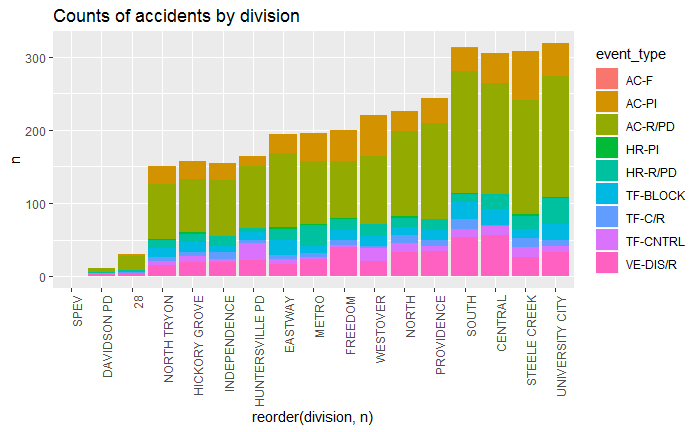

```r
ggplot(dist_accidents, aes(x = reorder(division,n), y = n, fill = event_type)) +
  geom_col() +
  labs(title="Counts of accidents by division") +
  theme(axis.text.x = element_text(angle = 90, hjust = 1))
```

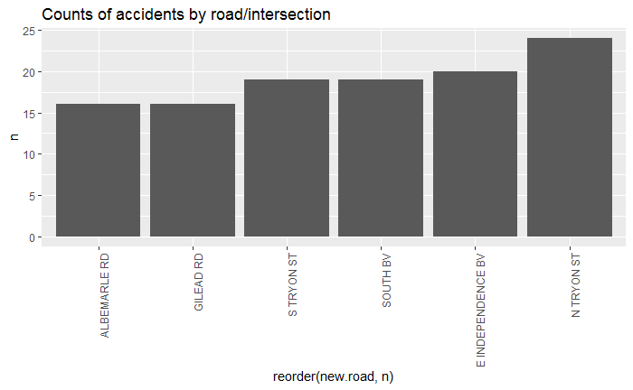

```r
ggplot(road_accidents, aes(x = reorder(new.road, n), y = n)) +
  geom_col() +
  labs(title="Counts of accidents by road/intersection") +
  theme(axis.text.x = element_text(angle = 90, hjust = 1))
```

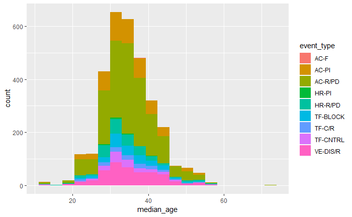

```r
ggplot(accidents, aes(x=median_age, fill = event_type)) +
    geom_histogram(bins = 20)
```

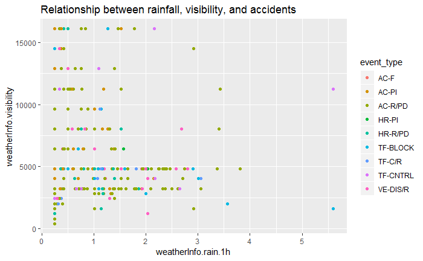

```r
ggplot(accidents, aes(x = weatherInfo.rain.1h, y = weatherInfo.visibility, color = event_type)) +
  geom_point() +
  labs(title="Relationship between rainfall, visibility, and accidents")
```

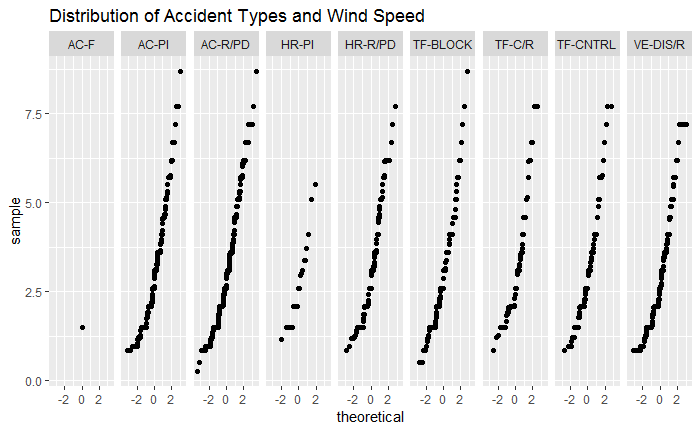

```r
ggplot(accidents, aes(sample = weatherInfo.wind.speed)) +
  stat_qq() +
  facet_wrap( ~ event_type, nrow = 1) +
  labs(title="Distribution of Accident Types and Wind Speed")
```

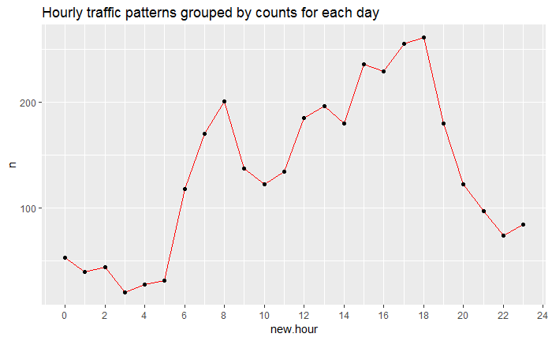

```r
ggplot(hour_accidents, aes(x = new.hour, y = n)) +
  geom_line(color="red") +
  scale_x_continuous(breaks = pretty(accidents$new.hour, n = 10)) +
  geom_point() +
  labs(title="Hourly traffic patterns grouped by counts for each day")
```

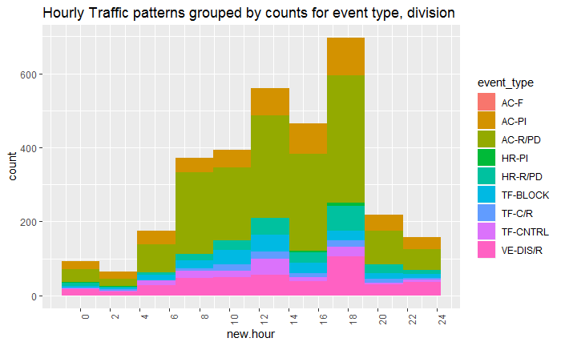

```r
ggplot(accidents, aes(x = new.hour, fill = event_type)) +
  geom_histogram(bins = 10) +
  labs(title="Hourly Traffic patterns grouped by counts for event type, division") +
  theme(axis.text.x = element_text(angle = 90, hjust = 1)) +
  scale_x_continuous(breaks = pretty(accidents$new.hour, n = 10))
```

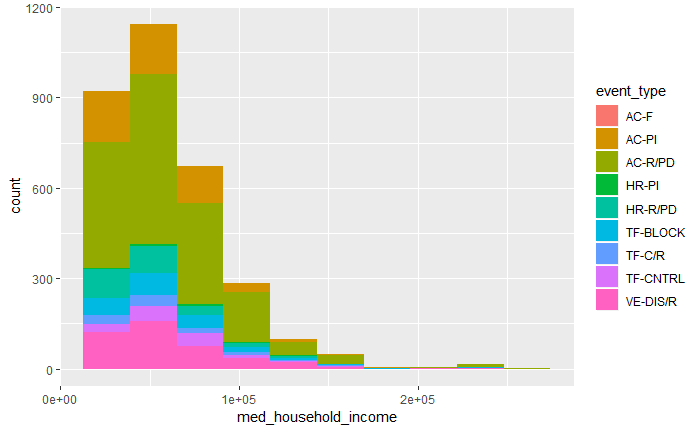

```r
ggplot(accidents, aes(x=med_household_income, fill = event_type)) +
    geom_histogram(bins = 10)
```

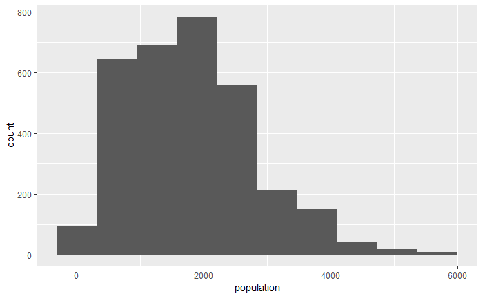

```r
ggplot(accidents, aes(x=population)) +
    geom_histogram(bins = 10)
```

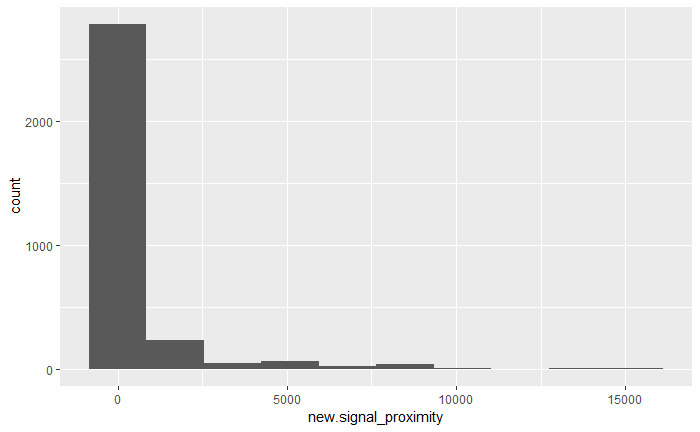

```r
ggplot(accidents, aes(x=new.signal_proximity)) +
    geom_histogram(bins = 10)
```

Correlation matrix for only numeric features, #TODO: transform categorical features to correct numeric representations

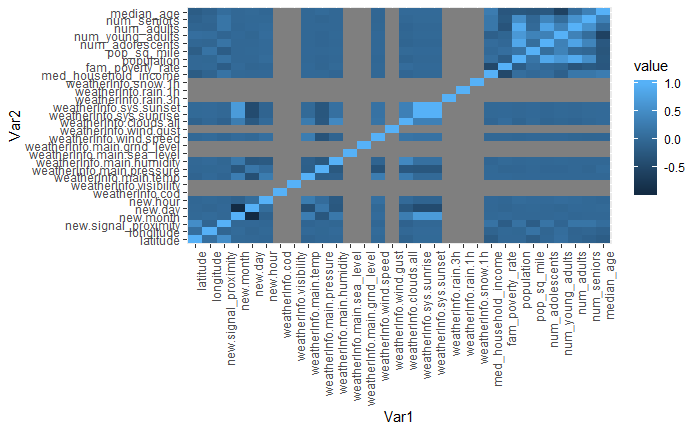

```r
accidents_matrix <- accidents %>%
    select_if(is.numeric) %>%
    cor(.)
melted_acc <- melt(accidents_matrix)
ggplot(data = melted_acc, aes(x=Var1, y=Var2, fill=value)) +
  geom_tile() +
  theme(axis.text.x = element_text(angle = 90, hjust = 1))
```

## Exploratory Modeling (To-Continue)

For creating training data, we will pick a random date/time that is applicable during normal hours, if this does not contain an accident we will place this in our non-accident bin. We should ensure our proportions are correct in that we should have roughly less accidents than our non-accidents as to preserve realism in our predictions.